# Poisson Regression & Zero-Inflated Poisson (ZIP) Models

February 03, 2026

## Learning goals

- Recognize when **Poisson regression** is appropriate for count data
- Understand the **mean = variance** property and why it can fail
- Explain the motivation for **excess zeros**
- Describe the structure of a **Zero-Inflated Poisson (ZIP)** model
- Interpret coefficients in the **count** and **zero** components

## Count data: when do we use Poisson models?

We model a nonnegative integer response:

\[ Y \in \{0,1,2,\ldots\} \]

**Examples** - ER visits in a year - Defects per item - Emails per day - Crashes at an intersection per month

## The Poisson distribution (review)

\[ P(Y=y) = \frac{e^{-\lambda}\lambda^y}{y!}, \qquad y=0,1,2,\ldots \]

Key properties:

\[ \mathbb{E}(Y)=\lambda, \qquad \mathrm{Var}(Y)=\lambda \]

So **mean = variance**.

## Poisson regression (GLM)

Model the mean count \(\lambda_i\) as a function of predictors:

\[ Y_i \sim \text{Poisson}(\lambda_i), \qquad \log(\lambda_i) = \mathbf{x}_i^\top \boldsymbol{\beta} \]

Why the log link?

- ensures \(\lambda_i>0\)
- leads to a clean multiplicative interpretation

## Interpreting coefficients in Poisson regression

From

\[ \log(\lambda_i)=\beta_0+\beta_1 x_{i1}+\cdots \]

A one-unit increase in \(x_j\) changes the mean by:

\[ \frac{\lambda_i(x_j+1)}{\lambda_i(x_j)} = e^{\beta_j} \]

So \(e^{\beta_j}\) is the **multiplicative factor** on the mean count.

## A common issue: too many zeros

In practice, we often see **more zeros** than a Poisson model expects.

**Examples** - doctor visits (many people never go) - insurance claims (many policyholders have none) - crashes (many locations have zero)

Consequences: - poor fit - underestimated standard errors - apparent overdispersion (\(\mathrm{Var}(Y) > \mathbb{E}(Y)\))

## Two kinds of zeros (intuition)

**Sampling zeros:**  
- could have been positive, but happened to be 0 this time  
- e.g., someone who *might* visit a doctor this year, but didn’t

**Structural zeros:**  
- outcome is essentially impossible / not at risk  
- e.g., someone without a car → 0 car crashes

ZIP explicitly models this mixture.

## Zero-Inflated Poisson (ZIP): the story

For each observation \(i\):

1. With probability \(\pi_i\), we are in a **structural zero** state
2. With probability \(1-\pi_i\), we are in the **count** state:

\[ Y_i \mid \text{count state} \sim \text{Poisson}(\lambda_i) \]

## ZIP probability model

\[ P(Y_i=0)=\pi_i + (1-\pi_i)e^{-\lambda_i} \]

\[ P(Y_i=y)= (1-\pi_i)\frac{e^{-\lambda_i}\lambda_i^y}{y!},\quad y\ge 1 \]

So ZIP adds a **spike at zero** on top of the Poisson distribution.

## ZIP has two linked regressions

**Zero (inflation) part**: models probability of structural zero

\[ \text{logit}(\pi_i)=\mathbf{z}_i^\top \boldsymbol{\gamma} \]

**Count part**: models mean count among the “at risk” group

\[ \log(\lambda_i)=\mathbf{x}_i^\top \boldsymbol{\beta} \]

Predictors \(\mathbf{x}_i\) and \(\mathbf{z}_i\) can be the same or different.

## Interpreting ZIP coefficients

- **Count coefficients** \(\beta\):  
  *Among those in the count state*, a one-unit increase in \(x_j\) multiplies the mean by \(e^{\beta_j}\).
- **Zero coefficients** \(\gamma\):  
  In the logit model, a one-unit increase in \(z_k\) multiplies the **odds** of being a structural zero by \(e^{\gamma_k}\).

## Visual intuition: Poisson vs ZIP

We simulate data with the same Poisson rate \(\lambda\) but extra zeros via \(\pi\).

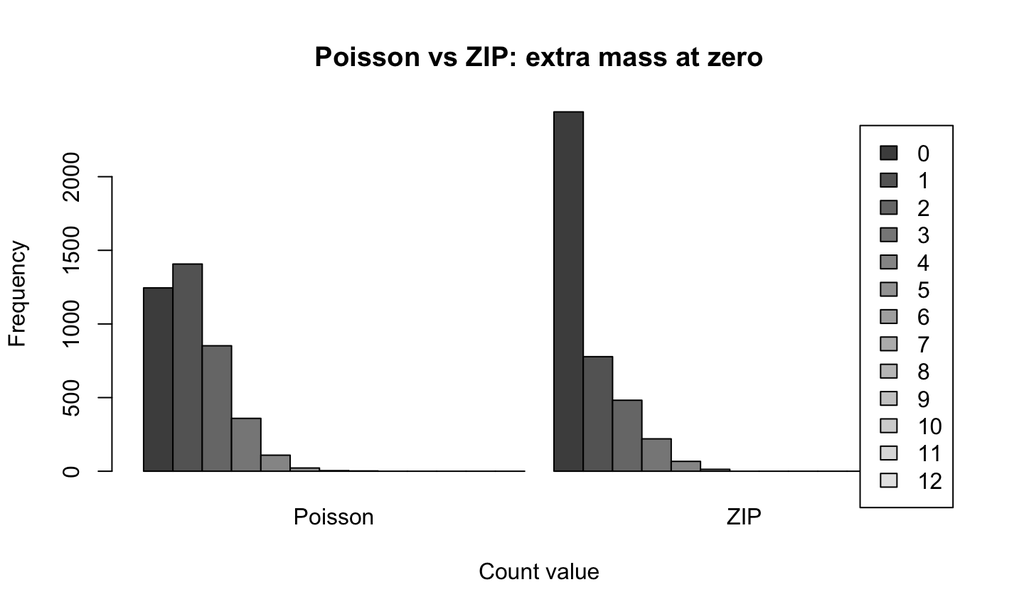

```r
set.seed(1)

n <- 4000
lambda <- 1.2
pi0 <- 0.45

# Poisson sample
y_pois <- rpois(n, lambda)

# ZIP sample: structural zeros with prob pi0, otherwise Poisson(lambda)
is_struct_zero <- rbinom(n, 1, pi0)
y_zip <- ifelse(is_struct_zero == 1, 0, rpois(n, lambda))

tab <- rbind(
  Poisson = table(factor(y_pois, levels = 0:12)),
  ZIP     = table(factor(y_zip,  levels = 0:12))
)

barplot(t(tab),
        beside = TRUE,
        legend.text = TRUE,
        xlab = "Count value",
        ylab = "Frequency",
        main = "Poisson vs ZIP: extra mass at zero")
```

## What ZIP is *not*

ZIP is not just “overdispersion” in general.

If variance > mean but zeros are not *structural*, consider:

- **Negative Binomial regression** (handles heterogeneity / overdispersion)
- **Quasi-Poisson** (robust SEs, not a full likelihood model)

ZIP is best when **two mechanisms** generate zeros.

## How do we decide between Poisson and ZIP?

Practical checks:

- Compare observed zeros vs expected zeros under Poisson
- Residual diagnostics / goodness of fit
- Likelihood-based comparisons (AIC/BIC) for fitted models
- Subject-matter reasoning: “not-at-risk” group plausible?

## Example (conceptual)

Suppose \(Y\) = number of clinic visits in a year.

- Some people are “never-users” (structural zeros)
- Others are at risk and have counts driven by health and access

ZIP lets you model:

- who is a never-user (zero model)
- how often users visit (count model)

## Fitting ZIP models in R

The `pscl` package provides `zeroinfl()`.

```r
# install.packages("pscl")
library(pscl)

# Example:
# y ~ x1 + x2 is the count model
# | z1 + z2 is the zero-inflation model
fit_zip <- zeroinfl(y ~ x1 + x2 | z1 + z2, dist = "poisson")
summary(fit_zip)
```

## Key takeaways

- **Poisson regression** models counts with \(\mathbb{E}(Y)=\mathrm{Var}(Y)\)
- Real data often have **excess zeros**
- **ZIP** combines:
  - a logistic model for structural zeros (\(\pi_i\))
  - a Poisson model for counts among at-risk units (\(\lambda_i\))
- Interpret coefficients separately in the two parts

## Quick check (in-class questions)

1. What does \(\pi_i\) represent in ZIP?
2. If \(\beta_1 = 0.2\), what is \(e^{\beta_1}\) and how do you interpret it?
3. Give an example where structural zeros are plausible.
4. When might Negative Binomial be more appropriate than ZIP?